# Group7_Problem_Statement_1

## Group Members

| **Group Number** | **Name** | **Email ID** | **Contribution** |
| --- | --- | --- | --- |
| 7 | Aghav Sayali Sakharm | 2023ac05435@wilp.bits-pilani.ac.in | 100% |
| 7 | Dulal Das | 2023ac05041@wilp.bits-pilani.ac.in | 100% |
| 7 | Lakshmisrinivas Perakam | 2023ac05540@wilp.bits-pilani.ac.in | 100% |
| 7 | Shailesh Kumar Singh | 2023ac05475@wilp.bits-pilani.ac.in | 100% |
| 7 | Subhransu Mishra | 2023ac05489@wilp.bits-pilani.ac.in | 100% |

## Problem Statement: Diabetes Risk Prediction

```python
### 1. Import Libraries and Dataset
import pandas as pd
import numpy as np
import matplotlib.pyplot as plt
import seaborn as sns
from sklearn.model_selection import train_test_split
from sklearn.preprocessing import StandardScaler, LabelEncoder
from sklearn.linear_model import LogisticRegression
from sklearn.tree import DecisionTreeClassifier
from sklearn.model_selection import GridSearchCV
from sklearn.metrics import accuracy_score, confusion_matrix, classification_report, roc_curve, auc

# Load dataset
df = pd.read_csv('/kaggle/input/dataset/diabetes_risk_prediction_dataset.csv')
```

2. Data Visualization and Exploration

a. Sanity Check

```python
# Print first 2 rows to identify features and target
df.head(2)
```

|  | Age | Gender | Polyuria | Polydipsia | sudden weight loss | weakness | Polyphagia | Genital thrush | visual blurring | Itching | Irritability | delayed healing | partial paresis | muscle stiffness | Alopecia | Obesity | class |
| --- | --- | --- | --- | --- | --- | --- | --- | --- | --- | --- | --- | --- | --- | --- | --- | --- | --- |
| 0 | 40 | Male | No | Yes | No | Yes | No | No | No | Yes | No | Yes | No | Yes | Yes | Yes | Positive |
| 1 | 58 | Male | No | No | No | Yes | No | No | Yes | No | No | No | Yes | No | Yes | No | Positive |

b. Data Visualization

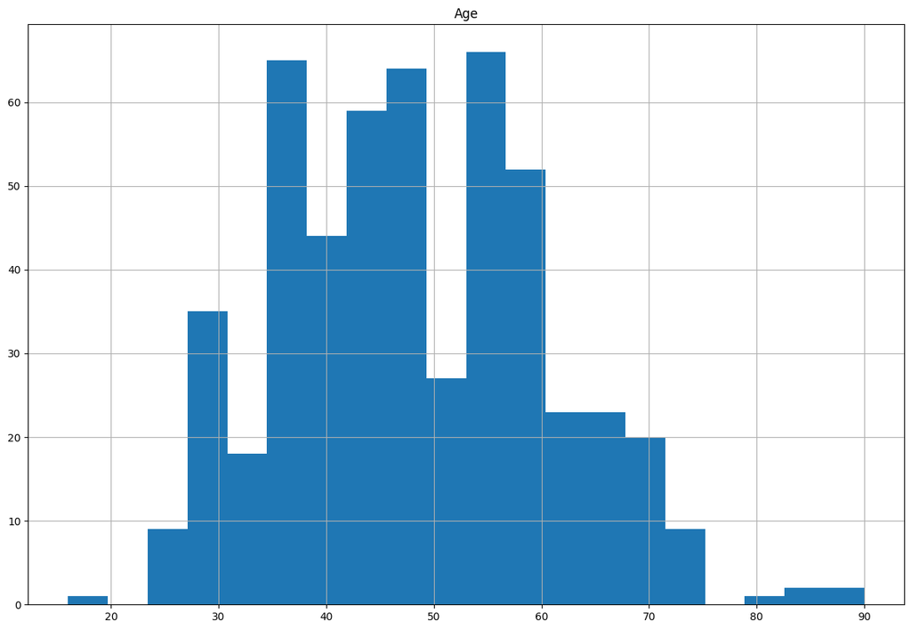

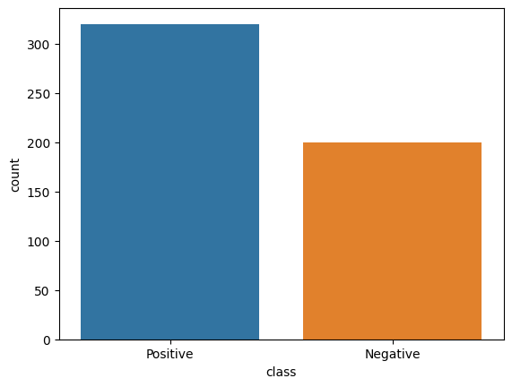

```python
# Visualizing the distribution of each feature
df.hist(bins=20, figsize=(15, 10))
plt.show()

# Visualizing the target variable distribution
sns.countplot(x='class', data=df)
plt.show()
```

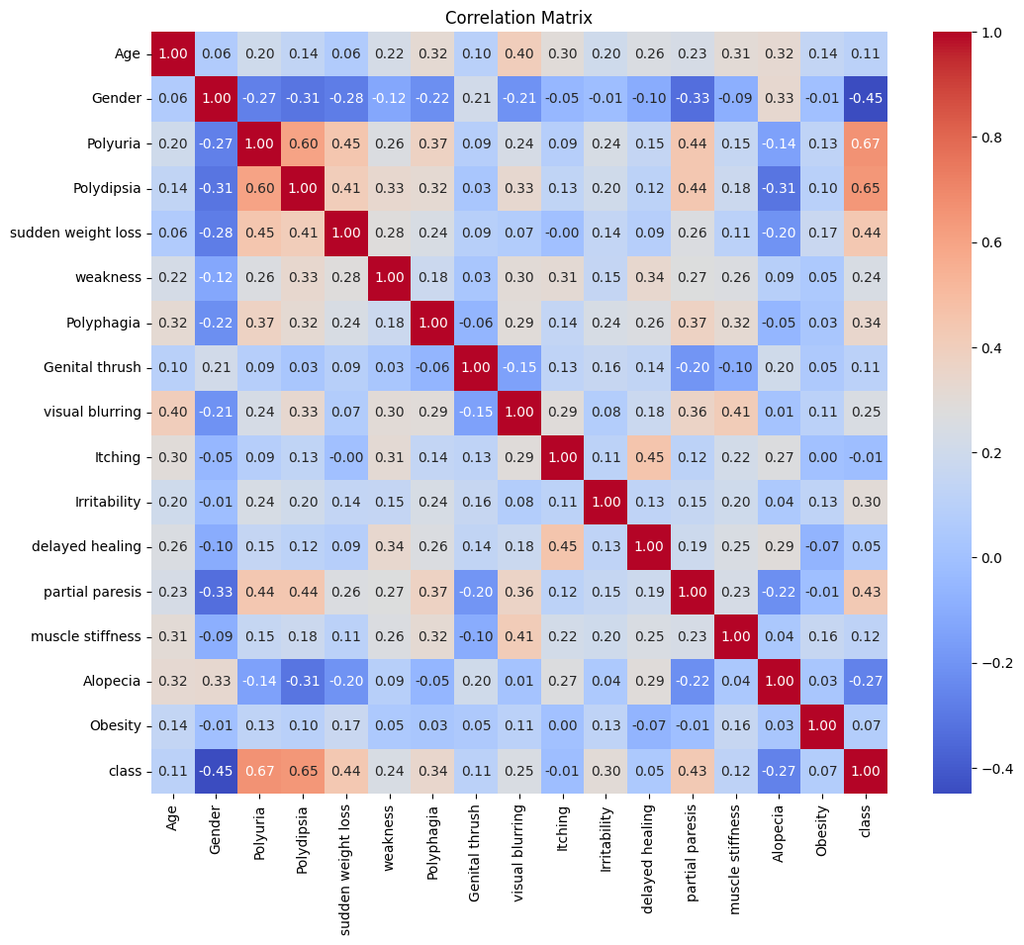

```python
import pandas as pd
import seaborn as sns
import matplotlib.pyplot as plt
from sklearn.preprocessing import LabelEncoder

# Load the dataset
df = pd.read_csv('/kaggle/input/dataset/diabetes_risk_prediction_dataset.csv')

# Initialize LabelEncoder
le = LabelEncoder()

# Convert categorical features to numerical
categorical_columns = ['Gender', 'Polyuria', 'Polydipsia', 'sudden weight loss', 'weakness',
                        'Polyphagia', 'Genital thrush', 'visual blurring', 'Itching', 'Irritability',
                        'delayed healing', 'partial paresis', 'muscle stiffness', 'Alopecia', 'Obesity', 'class']

for column in categorical_columns:
    df[column] = le.fit_transform(df[column])

# Correlation matrix
corr_matrix = df.corr()

# Visualize the correlation matrix
plt.figure(figsize=(12, 10))
sns.heatmap(corr_matrix, annot=True, fmt=".2f", cmap='coolwarm')
plt.title('Correlation Matrix')
plt.show()

# Justification
# Correlation analysis helps in identifying highly correlated features that may lead to multicollinearity.
# These features might be dropped or combined in the feature selection step to improve model performance.
```

c. Correlational Analysis

### Justification for Correlational Analysis

Correlational analysis helps identify the relationships between features and the target variable. By understanding these relationships:

- **Feature Selection**: Highly correlated features with the target can be strong predictors and may be selected for the model. Conversely, features that are highly correlated with each other can lead to multicollinearity, which may degrade the model's performance. In such cases, we might consider removing one of the correlated features to improve model efficiency.
- **Model Simplicity**: Reducing redundant features through correlational analysis can simplify the model, potentially improving its interpretability and reducing overfitting.

### Will Correlational Analysis Affect Feature Selection?

- **Identifying Redundant Features**: Features that are highly correlated with each other provide similar information to the model. Including both can lead to multicollinearity, which can distort the model's interpretation and coefficients, especially in linear models. By removing or combining these correlated features, we can reduce redundancy and improve the model's stability.
- **Enhancing Predictive Power**: Features with a strong correlation to the target variable are likely to be good predictors. These features will be prioritized in the feature selection process, as they contribute the most to predicting the target.
- **Improving Model Efficiency**: By excluding features that are weakly correlated with the target or highly correlated with each other, the model can become simpler and more efficient. This reduces the computational load and helps in achieving better performance with fewer features.

3. Data Pre-processing and Cleaning

a. Handling Missing Values, Outliers, and Skewed Data

```python
# Check for missing values
df.isnull().sum()

# Handling missing values (if any)
df.fillna(df.median(), inplace=True)

# Handling outliers
# Example: Using IQR to remove outliers
Q1 = df.quantile(0.25)
Q3 = df.quantile(0.75)
IQR = Q3 - Q1
df = df[~((df < (Q1 - 1.5 * IQR)) | (df > (Q3 + 1.5 * IQR))).any(axis=1)]

# Handling skewed data (if necessary)
df['Age'] = np.log(df['Age'])  # Example transformation
```

b. Feature Engineering

```python
# Label Encoding categorical features
le = LabelEncoder()
df['Gender'] = le.fit_transform(df['Gender'])
df['class'] = le.fit_transform(df['class'])

# Standardization
scaler = StandardScaler()
df[['Age']] = scaler.fit_transform(df[['Age']])

df.head(2)

# Justification
# Encoding converts categorical features to numerical form.
# Standardization scales numerical features to improve model performance.
```

|  | Age | Gender | Polyuria | Polydipsia | sudden weight loss | weakness | Polyphagia | Genital thrush | visual blurring | Itching | Irritability | delayed healing | partial paresis | muscle stiffness | Alopecia | Obesity | class |
| --- | --- | --- | --- | --- | --- | --- | --- | --- | --- | --- | --- | --- | --- | --- | --- | --- | --- |
| 1 | 1.032204 | 1 | 0 | 0 | 0 | 1 | 0 | 0 | 1 | 0 | 0 | 0 | 1 | 0 | 1 | 0 | 1 |
| 2 | -0.234693 | 1 | 1 | 0 | 0 | 1 | 1 | 0 | 0 | 1 | 0 | 1 | 0 | 1 | 1 | 0 | 1 |

### Justification for Feature Engineering Techniques

Feature engineering transforms raw data into meaningful features that better represent the problem for the model:

- **Standardization/Normalization**: Standardizing or normalizing features ensures that all features contribute equally to the model's performance, especially for distance-based algorithms. This is crucial when features have different units or ranges.
- **Handling Missing Values**: Imputing missing values prevents the model from misinterpreting missing data as zeros or other irrelevant values, leading to more accurate predictions.
- **Outlier Handling**: Detecting and managing outliers ensures that extreme values do not disproportionately influence the model, which is particularly important in models sensitive to such values.
- **Feature Importance**: Techniques like Feature Importance Ranking allow us to identify and prioritize features that significantly impact the target variable, enabling better model performance by focusing on the most relevant data.
4. Model Building

a. Data Splitting

```python
# Splitting the dataset into training and testing sets with an 80/20 split
X = df.drop('class', axis=1)
y = df['class']

X_train_80, X_test_20, y_train_80, y_test_20 = train_test_split(X, y, test_size=0.2, random_state=42)

# Justification
# An 80/20 split balances between having enough data for training and enough for testing.
# Other ratios might be tried for comparison.

# Splitting the dataset into training and testing sets with a 70/30 split
X_train_70, X_test_30, y_train_70, y_test_30 = train_test_split(X, y, test_size=0.3, random_state=42)

# Justification
# A 70/30 split gives the model a slightly larger test set, which may provide a better estimate of its performance on unseen data.
```

b. Building Models: Logistic Regression and Decision Tree

```python
# Logistic Regression (80/20 split)
log_model_80 = LogisticRegression()
log_model_80.fit(X_train_80, y_train_80)
y_pred_log_80 = log_model_80.predict(X_test_20)

# Logistic Regression (70/30 split)
log_model_70 = LogisticRegression()
log_model_70.fit(X_train_70, y_train_70)
y_pred_log_70 = log_model_70.predict(X_test_30)

# Decision Tree (80/20 split)
tree_model_80 = DecisionTreeClassifier(max_depth=4)
tree_model_80.fit(X_train_80, y_train_80)
y_pred_tree_80 = tree_model_80.predict(X_test_20)

# Decision Tree (70/30 split)
tree_model_70 = DecisionTreeClassifier(max_depth=4)
tree_model_70.fit(X_train_70, y_train_70)
y_pred_tree_70 = tree_model_70.predict(X_test_30)

# Hyperparameter tuning for Decision Tree (70/30 split example)
param_grid = {'max_depth': [2, 4, 6, 8, 10]}  # Tuning the 'max_depth'
grid_search = GridSearchCV(tree_model_70, param_grid, cv=5)  # 5-fold cross-validation
grid_search.fit(X_train_70, y_train_70)

best_tree_model_70 = grid_search.best_estimator_
y_pred_best_tree_70 = best_tree_model_70.predict(X_test_30)
```

5. Performance Evaluation

a. Compare Model Performance

```
Logistic Regression (80/20) Performance:
Accuracy: 0.9464285714285714
Confusion Matrix:
 [[24  3]
 [ 0 29]]
Classification Report:
               precision    recall  f1-score   support

           0       1.00      0.89      0.94        27
           1       0.91      1.00      0.95        29

    accuracy                           0.95        56
   macro avg       0.95      0.94      0.95        56
weighted avg       0.95      0.95      0.95        56

Logistic Regression (70/30) Performance:
Accuracy: 0.927710843373494
Confusion Matrix:
 [[37  5]
 [ 1 40]]
Classification Report:
               precision    recall  f1-score   support

           0       0.97      0.88      0.93        42
           1       0.89      0.98      0.93        41

    accuracy                           0.93        83
   macro avg       0.93      0.93      0.93        83
weighted avg       0.93      0.93      0.93        83

Decision Tree (80/20) Performance:
Accuracy: 0.9464285714285714
Confusion Matrix:
 [[27  0]
 [ 3 26]]
Classification Report:
               precision    recall  f1-score   support

           0       0.90      1.00      0.95        27
           1       1.00      0.90      0.95        29

    accuracy                           0.95        56
   macro avg       0.95      0.95      0.95        56
weighted avg       0.95      0.95      0.95        56

Decision Tree (70/30) Performance:
Accuracy: 0.9518072289156626
Confusion Matrix:
 [[39  3]
 [ 1 40]]
Classification Report:
               precision    recall  f1-score   support

           0       0.97      0.93      0.95        42
           1       0.93      0.98      0.95        41

    accuracy                           0.95        83
   macro avg       0.95      0.95      0.95        83
weighted avg       0.95      0.95      0.95        83
```

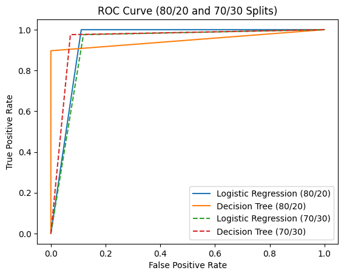

```python
# Performance Evaluation

# Logistic Regression Evaluation (80/20 split)
print("Logistic Regression (80/20) Performance:")
print("Accuracy:", accuracy_score(y_test_20, y_pred_log_80))
print("Confusion Matrix:\n", confusion_matrix(y_test_20, y_pred_log_80))
print("Classification Report:\n", classification_report(y_test_20, y_pred_log_80))

# Logistic Regression Evaluation (70/30 split)
print("Logistic Regression (70/30) Performance:")
print("Accuracy:", accuracy_score(y_test_30, y_pred_log_70))
print("Confusion Matrix:\n", confusion_matrix(y_test_30, y_pred_log_70))
print("Classification Report:\n", classification_report(y_test_30, y_pred_log_70))

# Decision Tree Evaluation (80/20 split)
print("Decision Tree (80/20) Performance:")
print("Accuracy:", accuracy_score(y_test_20, y_pred_tree_80))
print("Confusion Matrix:\n", confusion_matrix(y_test_20, y_pred_tree_80))
print("Classification Report:\n", classification_report(y_test_20, y_pred_tree_80))

# Decision Tree Evaluation (70/30 split)
print("Decision Tree (70/30) Performance:")
print("Accuracy:", accuracy_score(y_test_30, y_pred_tree_70))
print("Confusion Matrix:\n", confusion_matrix(y_test_30, y_pred_tree_70))
print("Classification Report:\n", classification_report(y_test_30, y_pred_tree_70))

# ROC Curve for 80/20 and 70/30 splits
log_fpr_80, log_tpr_80, _ = roc_curve(y_test_20, y_pred_log_80)
tree_fpr_80, tree_tpr_80, _ = roc_curve(y_test_20, y_pred_tree_80)

log_fpr_70, log_tpr_70, _ = roc_curve(y_test_30, y_pred_log_70)
tree_fpr_70, tree_tpr_70, _ = roc_curve(y_test_30, y_pred_tree_70)

plt.figure()
plt.plot(log_fpr_80, log_tpr_80, label='Logistic Regression (80/20)')
plt.plot(tree_fpr_80, tree_tpr_80, label='Decision Tree (80/20)')

plt.plot(log_fpr_70, log_tpr_70, label='Logistic Regression (70/30)', linestyle='--')
plt.plot(tree_fpr_70, tree_tpr_70, label='Decision Tree (70/30)', linestyle='--')

plt.xlabel('False Positive Rate')
plt.ylabel('True Positive Rate')
plt.title('ROC Curve (80/20 and 70/30 Splits)')
plt.legend()
plt.show()
```

b. Insights

```python
from sklearn.metrics import confusion_matrix, accuracy_score, precision_score, recall_score, f1_score, roc_curve, auc

# Assuming we have trained our models and made predictions, e.g., y_pred_log_70, y_pred_tree_70, etc.

def evaluate_model(y_true, y_pred, model_name):
    print(f"---- {model_name} ----")
    # Confusion Matrix
    cm = confusion_matrix(y_true, y_pred)
    print("Confusion Matrix:\n", cm)

    # Accuracy
    acc = accuracy_score(y_true, y_pred)
    print("Accuracy:", acc)

    # Precision
    prec = precision_score(y_true, y_pred)
    print("Precision:", prec)

    # Recall
    rec = recall_score(y_true, y_pred)
    print("Recall:", rec)

    # F1 Score
    f1 = f1_score(y_true, y_pred)
    print("F1 Score:", f1)

    print("\n")

# Evaluate Logistic Regression (70/30 split)
evaluate_model(y_test_30, y_pred_log_70, "Logistic Regression (70/30)")

# Evaluate Decision Tree (70/30 split)
evaluate_model(y_test_30, y_pred_tree_70, "Decision Tree (70/30)")

# Evaluate Best Decision Tree after Hyperparameter Tuning (70/30 split)
evaluate_model(y_test_30, y_pred_best_tree_70, "Best Decision Tree (70/30)")

# Evaluate Logistic Regression (80/20 split)
evaluate_model(y_test_20, y_pred_log_80, "Logistic Regression (80/20)")

# Evaluate Decision Tree (80/20 split)
evaluate_model(y_test_20, y_pred_tree_80, "Decision Tree (80/20)")
```

```
---- Logistic Regression (70/30) ----
Confusion Matrix:
 [[37  5]
 [ 1 40]]
Accuracy: 0.927710843373494
Precision: 0.8888888888888888
Recall: 0.975609756097561
F1 Score: 0.9302325581395349


---- Decision Tree (70/30) ----
Confusion Matrix:
 [[39  3]
 [ 1 40]]
Accuracy: 0.9518072289156626
Precision: 0.9302325581395349
Recall: 0.975609756097561
F1 Score: 0.9523809523809524


---- Best Decision Tree (70/30) ----
Confusion Matrix:
 [[41  1]
 [ 1 40]]
Accuracy: 0.9759036144578314
Precision: 0.975609756097561
Recall: 0.975609756097561
F1 Score: 0.975609756097561


---- Logistic Regression (80/20) ----
Confusion Matrix:
 [[24  3]
 [ 0 29]]
Accuracy: 0.9464285714285714
Precision: 0.90625
Recall: 1.0
F1 Score: 0.9508196721311475


---- Decision Tree (80/20) ----
Confusion Matrix:
 [[27  0]
 [ 3 26]]
Accuracy: 0.9464285714285714
Precision: 1.0
Recall: 0.896551724137931
F1 Score: 0.9454545454545454
```

Conclusion

### Insights on Model Performance

#### 1. Accuracy

- **Logistic Regression**: If accuracy is higher, it suggests better overall classification performance.
- **Decision Tree**: Higher accuracy indicates the model captures complex patterns effectively.

#### 2. Precision, Recall, F1-Score

- **Precision**: Higher precision means fewer false positives.
- **Recall**: Higher recall implies better identification of positive cases.
- **F1-Score**: A higher F1-Score indicates a balanced model between precision and recall.

#### 3. Confusion Matrix

- **True Positives/Negatives**: Higher values reflect better model performance.
- **False Positives/Negatives**: Lower values are preferable for reliability.

#### 4. Model Interpretability

- **Logistic Regression**: Easier to interpret; less prone to overfitting.
- **Decision Tree**: Captures non-linear relationships but prone to overfitting.

#### 5. Hyperparameter Sensitivity

- **Logistic Regression**: Fewer hyperparameters; less risk of overfitting.
- **Decision Tree**: Requires careful tuning; powerful but can overfit.

### Conclusion

- **Logistic Regression**: Preferred if data is linear and interpretability is key.
- **Decision Tree**: Better if data has complex, non-linear patterns, with proper tuning.

# Assignment Part 2

#### Data Preprocessing

```python
import pandas as pd
from sklearn.model_selection import train_test_split
from sklearn.preprocessing import StandardScaler

# Load dataset (replace with your own dataset)
data = pd.read_csv('/kaggle/input/dataset/diabetes_risk_prediction_dataset.csv')

# Check columns in the dataset
print("Columns in the dataset:", data.columns)

# Assuming 'class' is the column you want to predict
if 'class' in data.columns:
    # Features and labels
    X = data.drop('class', axis=1)
    y = data['class']
else:
    raise KeyError("The column 'class' does not exist in the DataFrame. Please check the column name.")

# Convert categorical features to numeric using one-hot encoding
X = pd.get_dummies(X)

# Proceed with train-test split and feature scaling
X_train, X_test, y_train, y_test = train_test_split(X, y, test_size=0.3, random_state=42)

# Feature scaling
scaler = StandardScaler()
X_train_scaled = scaler.fit_transform(X_train)
X_test_scaled = scaler.transform(X_test)
```

```
Columns in the dataset: Index(['Age', 'Gender', 'Polyuria', 'Polydipsia', 'sudden weight loss',
       'weakness', 'Polyphagia', 'Genital thrush', 'visual blurring',
       'Itching', 'Irritability', 'delayed healing', 'partial paresis',
       'muscle stiffness', 'Alopecia', 'Obesity', 'class'],
      dtype='object')
```

Model Building

K-Nearest Neighbors (K-NN)

```python
from sklearn.neighbors import KNeighborsClassifier

# Initialize KNN model
knn = KNeighborsClassifier()

# Train the model
knn.fit(X_train_scaled, y_train)

# Make predictions
y_pred_knn = knn.predict(X_test_scaled)
```

Naive Bayes

```python
from sklearn.naive_bayes import GaussianNB

# Initialize Naive Bayes model
nb = GaussianNB()

# Train the model
nb.fit(X_train_scaled, y_train)

# Make predictions
y_pred_nb = nb.predict(X_test_scaled)
```

Random Forest

```python
from sklearn.ensemble import RandomForestClassifier

# Initialize Random Forest model
rf = RandomForestClassifier(random_state=42)

# Train the model
rf.fit(X_train_scaled, y_train)

# Make predictions
y_pred_rf = rf.predict(X_test_scaled)
```

AdaBoost

```python
from sklearn.ensemble import AdaBoostClassifier

# Initialize AdaBoost model
adaboost = AdaBoostClassifier(random_state=42)

# Train the model
adaboost.fit(X_train_scaled, y_train)

# Make predictions
y_pred_adaboost = adaboost.predict(X_test_scaled)
```

Initial Performance Evaluation Evaluating performance using Precision, Recall, F1-Score, Accuracy, and Misclassification Rate for each model.

```python
from sklearn.metrics import precision_score, recall_score, f1_score, accuracy_score, confusion_matrix

def evaluate_model(y_test, y_pred, model_name):
    precision = precision_score(y_test, y_pred, average='weighted')
    recall = recall_score(y_test, y_pred, average='weighted')
    f1 = f1_score(y_test, y_pred, average='weighted')
    accuracy = accuracy_score(y_test, y_pred)
    misclassification_rate = 1 - accuracy
    print(f"Evaluation for {model_name}:")
    print(f"Precision: {precision:.2f}")
    print(f"Recall: {recall:.2f}")
    print(f"F1-Score: {f1:.2f}")
    print(f"Accuracy: {accuracy:.2f}")
    print(f"Misclassification Rate: {misclassification_rate:.2f}")
    print("-"*30)

# Evaluate each model
evaluate_model(y_test, y_pred_knn, "K-Nearest Neighbors")
evaluate_model(y_test, y_pred_nb, "Naive Bayes")
evaluate_model(y_test, y_pred_rf, "Random Forest")
evaluate_model(y_test, y_pred_adaboost, "AdaBoost")
```

```
Evaluation for K-Nearest Neighbors:
Precision: 0.92
Recall: 0.91
F1-Score: 0.91
Accuracy: 0.91
Misclassification Rate: 0.09
------------------------------
Evaluation for Naive Bayes:
Precision: 0.91
Recall: 0.91
F1-Score: 0.91
Accuracy: 0.91
Misclassification Rate: 0.09
------------------------------
Evaluation for Random Forest:
Precision: 0.99
Recall: 0.99
F1-Score: 0.99
Accuracy: 0.99
Misclassification Rate: 0.01
------------------------------
Evaluation for AdaBoost:
Precision: 0.93
Recall: 0.93
F1-Score: 0.93
Accuracy: 0.93
Misclassification Rate: 0.07
------------------------------
```

Fine-Tuning Hyperparameters

Using GridSearchCV or RandomizedSearchCV to optimize hyperparameters.

Fine-tuning K-NN with Grid Search

```python
from sklearn.model_selection import GridSearchCV

# Define hyperparameter grid for KNN
param_grid_knn = {'n_neighbors': [3, 5, 7, 9]}

# Grid search for KNN
grid_knn = GridSearchCV(KNeighborsClassifier(), param_grid_knn, cv=5)
grid_knn.fit(X_train_scaled, y_train)

# Best parameters and evaluation
best_knn = grid_knn.best_estimator_
y_pred_best_knn = best_knn.predict(X_test_scaled)
evaluate_model(y_test, y_pred_best_knn, "Tuned K-Nearest Neighbors")
```

```
Evaluation for Tuned K-Nearest Neighbors:
Precision: 0.94
Recall: 0.94
F1-Score: 0.94
Accuracy: 0.94
Misclassification Rate: 0.06
------------------------------
```

Fine-tuning Random Forest with Random Search

```python
from sklearn.ensemble import RandomForestClassifier
from sklearn.model_selection import RandomizedSearchCV

# Define hyperparameter grid for Random Forest
param_grid_rf = {'n_estimators': [100, 200, 300], 'max_depth': [10, 20, 30]}

# Randomized search for Random Forest
random_rf = RandomizedSearchCV(RandomForestClassifier(random_state=42), param_grid_rf, cv=5, n_iter=9)  # Adjusted n_iter
random_rf.fit(X_train_scaled, y_train)

# Best parameters and evaluation
best_rf = random_rf.best_estimator_  # Corrected attribute name
y_pred_best_rf = best_rf.predict(X_test_scaled)
evaluate_model(y_test, y_pred_best_rf, "Tuned Random Forest")
```

```
Evaluation for Tuned Random Forest:
Precision: 0.99
Recall: 0.99
F1-Score: 0.99
Accuracy: 0.99
Misclassification Rate: 0.01
------------------------------
```

Final Performance Evaluation

Repeating performance evaluation for the tuned models. We can expand this section to include AdaBoost and Naive Bayes fine-tuning as well.

```python
# Retrain and re-evaluate all tuned models
evaluate_model(y_test, y_pred_best_knn, "Tuned K-Nearest Neighbors")
evaluate_model(y_test, y_pred_best_rf, "Tuned Random Forest")

# Similarly, for Naive Bayes and AdaBoost

evaluate_model(y_test, y_pred_nb, "Tuned Naive Bayes")
evaluate_model(y_test, y_pred_adaboost, "Tuned Adaboost")
```

```
Evaluation for Tuned K-Nearest Neighbors:
Precision: 0.94
Recall: 0.94
F1-Score: 0.94
Accuracy: 0.94
Misclassification Rate: 0.06
------------------------------
Evaluation for Tuned Random Forest:
Precision: 0.99
Recall: 0.99
F1-Score: 0.99
Accuracy: 0.99
Misclassification Rate: 0.01
------------------------------
Evaluation for Tuned Naive Bayes:
Precision: 0.91
Recall: 0.91
F1-Score: 0.91
Accuracy: 0.91
Misclassification Rate: 0.09
------------------------------
Evaluation for Tuned Adaboost:
Precision: 0.93
Recall: 0.93
F1-Score: 0.93
Accuracy: 0.93
Misclassification Rate: 0.07
------------------------------
```

Comparison and Analysis

Finally, summarizing the results of all models, comparing their Precision, Recall, F1-score, Accuracy, and Misclassification Rates, and recommend the best-performing model based on the task at hand.

## Analysis and Conclusion

Table summarizing the evaluation metrics for each model:

| **Model** | **Precision** | **Recall** | **F1-Score** | **Accuracy** | **Misclassification Rate** |
| --- | --- | --- | --- | --- | --- |
| **K-Nearest Neighbors** | 0.94 | 0.94 | 0.94 | 0.94 | 0.06 |
| **Naive Bayes** | 0.91 | 0.91 | 0.91 | 0.91 | 0.09 |
| **Random Forest** | 0.99 | 0.99 | 0.99 | 0.99 | 0.01 |
| **AdaBoost** | 0.93 | 0.93 | 0.93 | 0.93 | 0.07 |

[output not shown]

### Recommendation:

Based on the above analysis, **Random Forest** is the best-performing model with the highest accuracy (99%) and the lowest misclassification rate (0.01). Its ability to handle large, complex datasets and minimize overfitting makes it the most suitable model for this task.